# chapter3

## *Part 2) Data analysis*

Now that we prepared the data, let’s go for analysing the data

```r
# read the data from your computer drive
data_student_perf_alc = read.csv("alc_joinet.csv")

#Alternatively you can read from the URL:
data_student_perf_alc <- read.table("http://s3.amazonaws.com/assets.datacamp.com/production/course_2218/datasets/alc.txt", sep=",", header=TRUE)
```

**Data description**:  
This data approach student achievement in secondary education of two Portuguese schools. The data attributes include student grades, demographic, social and school related features) and it was collected by using school reports and questionnaires. Two datasets are provided regarding the performance in two distinct subjects: Mathematics (mat) and Portuguese language (por). We joint the two dataset and now are ready to go for analysis phase.  
Thus, we will use this dataset to analysis the relationships between high/low alcohol consumption and other variables. Is there any relationship between students performance and alcohol? Logistic regression will be used. ___For more info visit: https://archive.ics.uci.edu/ml/datasets/Student+Performance___

```r
# Variables names are as following
colnames(data_student_perf_alc)
```

```
##  [1] "school"     "sex"        "age"        "address"    "famsize"
##  [6] "Pstatus"    "Medu"       "Fedu"       "Mjob"       "Fjob"
## [11] "reason"     "nursery"    "internet"   "guardian"   "traveltime"
## [16] "studytime"  "failures"   "schoolsup"  "famsup"     "paid"
## [21] "activities" "higher"     "romantic"   "famrel"     "freetime"
## [26] "goout"      "Dalc"       "Walc"       "health"     "absences"
## [31] "G1"         "G2"         "G3"         "alc_use"    "high_use"
```

I would like to select 4 interesting variables to start modelling. they are as following:  
1. *Internet*: students with high Internet access at home, will consume less alcohol  
2. *goout*: students who go out with friend more, will consume more alcohol  
3. *absences*: students who are often absent from class, consume more alcohol  
4. *activities*: students with higher extra-curricular activities will consume less alcohol

```r
# select only those columns
variables <- c("internet", "goout", "absences", "activities",
               "alc_use", "high_use")

dt_some_col =select(data_student_perf_alc, variables)
```

```
## Note: Using an external vector in selections is ambiguous.
## i Use `all_of(variables)` instead of `variables` to silence this message.
## i See <https://tidyselect.r-lib.org/reference/faq-external-vector.html>.
```

```r
dim(dt_some_col)
```

```
## [1] 382   6
```

Draw a bar plot of each variable

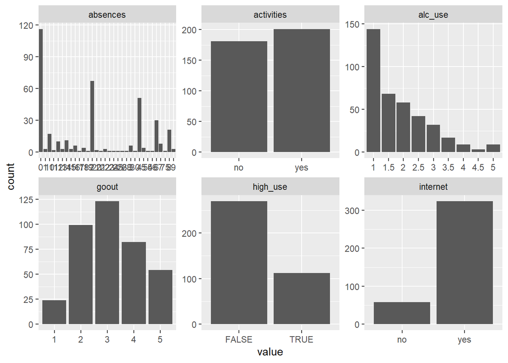

```r
gather(dt_some_col) %>% ggplot(aes(value)) + facet_wrap("key", scales = "free") + geom_bar()
```

```r
# see the proportional table
table(dt_some_col$absences)/nrow(dt_some_col)*100
```

```
##
##          0          1          2          3          4          5          6
## 30.3664921  0.7853403 17.5392670  1.5706806 13.3507853  1.0471204  7.8534031
##          7          8          9         10         11         12         13
##  2.0942408  5.4973822  0.7853403  4.4502618  0.5235602  2.6178010  0.7853403
##         14         15         16         17         18         19         20
##  2.8795812  0.7853403  1.5706806  0.2617801  1.0471204  0.2617801  0.5235602
##         21         22         23         24         25         26         28
##  0.2617801  0.7853403  0.2617801  0.2617801  0.2617801  0.2617801  0.2617801
##         30         54         56         75
##  0.2617801  0.2617801  0.2617801  0.2617801
```

```r
#data structure
str(dt_some_col)
```

```
## 'data.frame':    382 obs. of  6 variables:
##  $ internet  : chr  "no" "yes" "yes" "yes" ...
##  $ goout     : int  4 3 2 2 2 2 4 4 2 1 ...
##  $ absences  : int  6 4 10 2 4 10 0 6 0 0 ...
##  $ activities: chr  "no" "no" "no" "yes" ...
##  $ alc_use   : num  1 1 2.5 1 1.5 1.5 1 1 1 1 ...
##  $ high_use  : logi  FALSE FALSE TRUE FALSE FALSE FALSE ...
```

```r
#Crosstable
cross_table = xtabs(~alc_use + internet, data = dt_some_col)
cross_table
```

```
##        internet
## alc_use  no yes
##     1    27 117
##     1.5   7  61
##     2     9  49
##     2.5   5  37
##     3     6  26
##     3.5   2  15
##     4     2   7
##     4.5   0   3
##     5     0   9
```

### **Extra coding 2: Calculate the proportion of each variable in table, rounding to 2 decimals**

```r
round(prop.table(cross_table), 2)
```

```
##        internet
## alc_use   no  yes
##     1   0.07 0.31
##     1.5 0.02 0.16
##     2   0.02 0.13
##     2.5 0.01 0.10
##     3   0.02 0.07
##     3.5 0.01 0.04
##     4   0.01 0.02
##     4.5 0.00 0.01
##     5   0.00 0.02
```

```r
#shows if distrubution is significantly differnet
chisq.test(cross_table)
```

```
## Warning in chisq.test(cross_table): Chi-squared approximation may be incorrect
```

```
##
##  Pearson's Chi-squared test
##
## data:  cross_table
## X-squared = 6.0051, df = 8, p-value = 0.6467
```

As p-value > 0.05, thus the distrubution of this variable (internet access at home) is not significantly differnet  
Note: don’t worry about the warning message, becuase the number of data is few.

For nother variable

```r
#Crosstable
cross_table = xtabs(~alc_use + goout, data = dt_some_col)
cross_table
```

```
##        goout
## alc_use  1  2  3  4  5
##     1   16 49 45 25  9
##     1.5  3 22 29  8  6
##     2    2 13 26 10  7
##     2.5  2  7 13 16  4
##     3    0  4  3 14 11
##     3.5  1  2  4  3  7
##     4    0  0  1  5  3
##     4.5  0  1  0  1  1
##     5    0  1  2  0  6
```

```r
# to get proportion of each, with 2 decimal rounded
round(prop.table(cross_table), 2)
```

```
##        goout
## alc_use    1    2    3    4    5
##     1   0.04 0.13 0.12 0.07 0.02
##     1.5 0.01 0.06 0.08 0.02 0.02
##     2   0.01 0.03 0.07 0.03 0.02
##     2.5 0.01 0.02 0.03 0.04 0.01
##     3   0.00 0.01 0.01 0.04 0.03
##     3.5 0.00 0.01 0.01 0.01 0.02
##     4   0.00 0.00 0.00 0.01 0.01
##     4.5 0.00 0.00 0.00 0.00 0.00
##     5   0.00 0.00 0.01 0.00 0.02
```

```r
#if distrubution is signoficantly differnet
chisq.test(cross_table)
```

```
## Warning in chisq.test(cross_table): Chi-squared approximation may be incorrect
```

```
##
##  Pearson's Chi-squared test
##
## data:  cross_table
## X-squared = 108.14, df = 32, p-value = 3.414e-10
```

As p-value < 0.05, thus the distrubution of this variable (going out behaviour) is significantly differnet  
Note: don’t worry about the warning message, becuase the number of data is few.

Yet, for another variable

```r
#Crosstable
cross_table = xtabs(~alc_use + absences, data = dt_some_col)
#cross_table
# to get proportion of each, with 2 decimal rounded
round(prop.table(cross_table), 2)
```

```
##        absences
## alc_use    0    1    2    3    4    5    6    7    8    9   10   11   12   13
##     1   0.15 0.01 0.07 0.00 0.04 0.00 0.03 0.01 0.02 0.01 0.01 0.00 0.01 0.00
##     1.5 0.06 0.00 0.04 0.00 0.03 0.00 0.01 0.00 0.01 0.00 0.01 0.00 0.01 0.00
##     2   0.04 0.00 0.03 0.01 0.02 0.01 0.01 0.01 0.01 0.00 0.01 0.00 0.00 0.00
##     2.5 0.02 0.00 0.01 0.01 0.01 0.00 0.01 0.01 0.00 0.00 0.01 0.00 0.01 0.00
##     3   0.02 0.00 0.02 0.00 0.01 0.00 0.00 0.00 0.01 0.00 0.00 0.00 0.00 0.00
##     3.5 0.01 0.00 0.00 0.00 0.01 0.00 0.00 0.00 0.01 0.00 0.00 0.00 0.00 0.00
##     4   0.00 0.00 0.00 0.00 0.01 0.00 0.01 0.00 0.00 0.00 0.00 0.00 0.00 0.00
##     4.5 0.00 0.00 0.00 0.00 0.00 0.00 0.00 0.00 0.00 0.00 0.00 0.00 0.00 0.00
##     5   0.00 0.00 0.00 0.00 0.01 0.00 0.00 0.00 0.00 0.00 0.00 0.00 0.00 0.00
##        absences
## alc_use   14   15   16   17   18   19   20   21   22   23   24   25   26   28
##     1   0.00 0.00 0.00 0.00 0.00 0.00 0.00 0.00 0.00 0.00 0.00 0.00 0.00 0.00
##     1.5 0.01 0.00 0.00 0.00 0.00 0.00 0.00 0.00 0.00 0.00 0.00 0.00 0.00 0.00
##     2   0.01 0.00 0.00 0.00 0.00 0.00 0.00 0.00 0.00 0.00 0.00 0.00 0.00 0.00
##     2.5 0.00 0.00 0.00 0.00 0.00 0.00 0.00 0.00 0.01 0.00 0.00 0.00 0.00 0.00
##     3   0.00 0.01 0.00 0.00 0.00 0.00 0.00 0.00 0.00 0.00 0.00 0.00 0.00 0.00
##     3.5 0.00 0.00 0.00 0.00 0.00 0.00 0.00 0.00 0.00 0.00 0.00 0.00 0.00 0.00
##     4   0.00 0.00 0.00 0.00 0.00 0.00 0.00 0.00 0.00 0.00 0.00 0.00 0.00 0.00
##     4.5 0.00 0.00 0.00 0.00 0.00 0.00 0.00 0.00 0.00 0.00 0.00 0.00 0.00 0.00
##     5   0.00 0.00 0.01 0.00 0.00 0.00 0.00 0.00 0.00 0.00 0.00 0.00 0.00 0.00
##        absences
## alc_use   30   54   56   75
##     1   0.00 0.00 0.00 0.00
##     1.5 0.00 0.00 0.00 0.00
##     2   0.00 0.00 0.00 0.00
##     2.5 0.00 0.00 0.00 0.00
##     3   0.00 0.00 0.00 0.00
##     3.5 0.00 0.00 0.00 0.00
##     4   0.00 0.00 0.00 0.00
##     4.5 0.00 0.00 0.00 0.00
##     5   0.00 0.00 0.00 0.00
```

```r
#if distrubution is signoficantly differnet
chisq.test(cross_table)
```

```
## Warning in chisq.test(cross_table): Chi-squared approximation may be incorrect
```

```
##
##  Pearson's Chi-squared test
##
## data:  cross_table
## X-squared = 348.17, df = 248, p-value = 2.751e-05
```

As p-value < 0.05, thus the distribution of this variable (absence) is significantly different.  
Note: don’t worry about the warning message, because the number of data is few.

Yet, for nother variable

```r
#Crosstable
cross_table = xtabs(~alc_use + activities, data = dt_some_col)
cross_table
```

```
##        activities
## alc_use no yes
##     1   58  86
##     1.5 40  28
##     2   24  34
##     2.5 22  20
##     3   18  14
##     3.5 10   7
##     4    4   5
##     4.5  1   2
##     5    4   5
```

```r
# to get proportion of each, with 2 decimal rounded
round(prop.table(cross_table), 2)
```

```
##        activities
## alc_use   no  yes
##     1   0.15 0.23
##     1.5 0.10 0.07
##     2   0.06 0.09
##     2.5 0.06 0.05
##     3   0.05 0.04
##     3.5 0.03 0.02
##     4   0.01 0.01
##     4.5 0.00 0.01
##     5   0.01 0.01
```

```r
#if distrubution is signoficantly differnet
chisq.test(cross_table)
```

```
## Warning in chisq.test(cross_table): Chi-squared approximation may be incorrect
```

```
##
##  Pearson's Chi-squared test
##
## data:  cross_table
## X-squared = 9.9466, df = 8, p-value = 0.2688
```

As p-value > 0.05, thus the distribution of this variable (extra-curricular activities) is not significantly different.  
Note: don’t worry about the warning message, because the number of data is few.

Let’s barplot the variables of interest

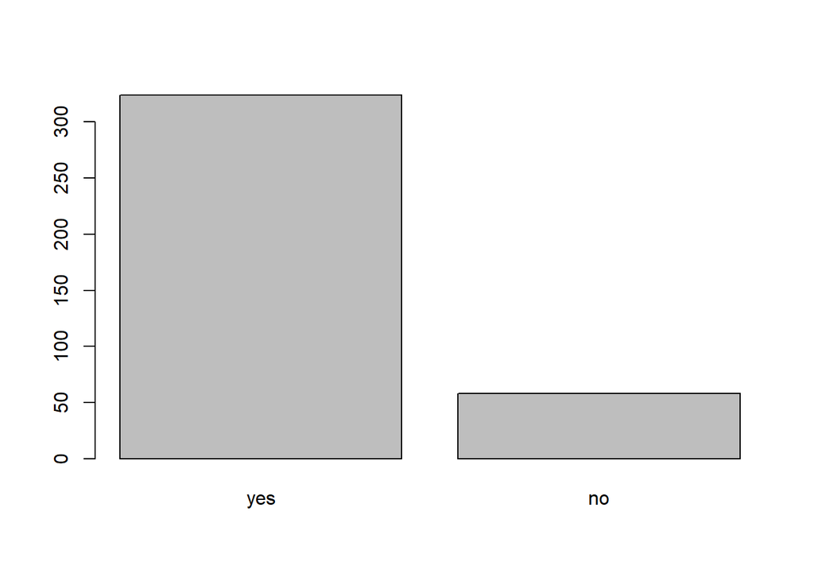

```r
barplot(sort(table(dt_some_col$internet),decreasing=T))
```

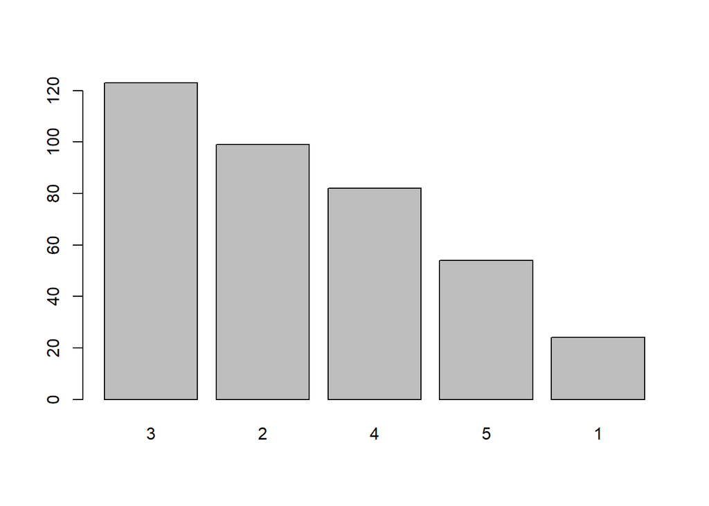

```r
barplot(sort(table(dt_some_col$goout),decreasing=T))
```

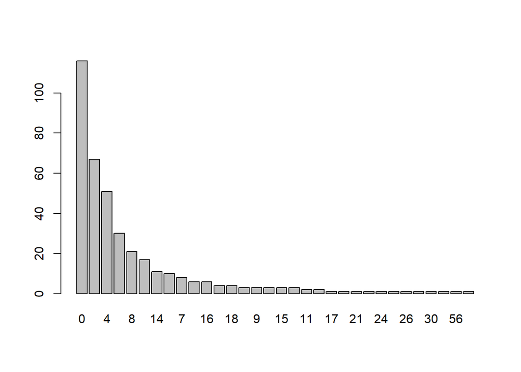

```r
barplot(sort(table(dt_some_col$absences),decreasing=T))
```

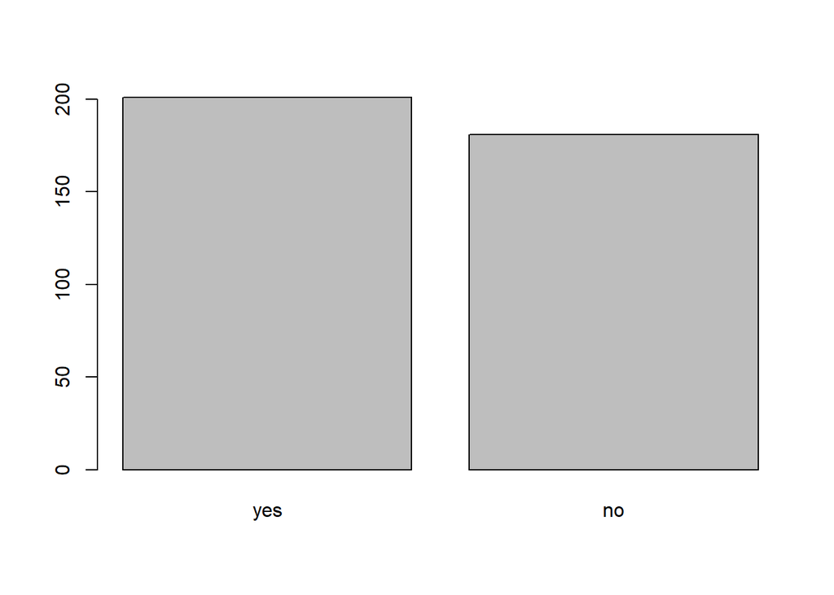

```r
barplot(sort(table(dt_some_col$activities),decreasing=T))
```

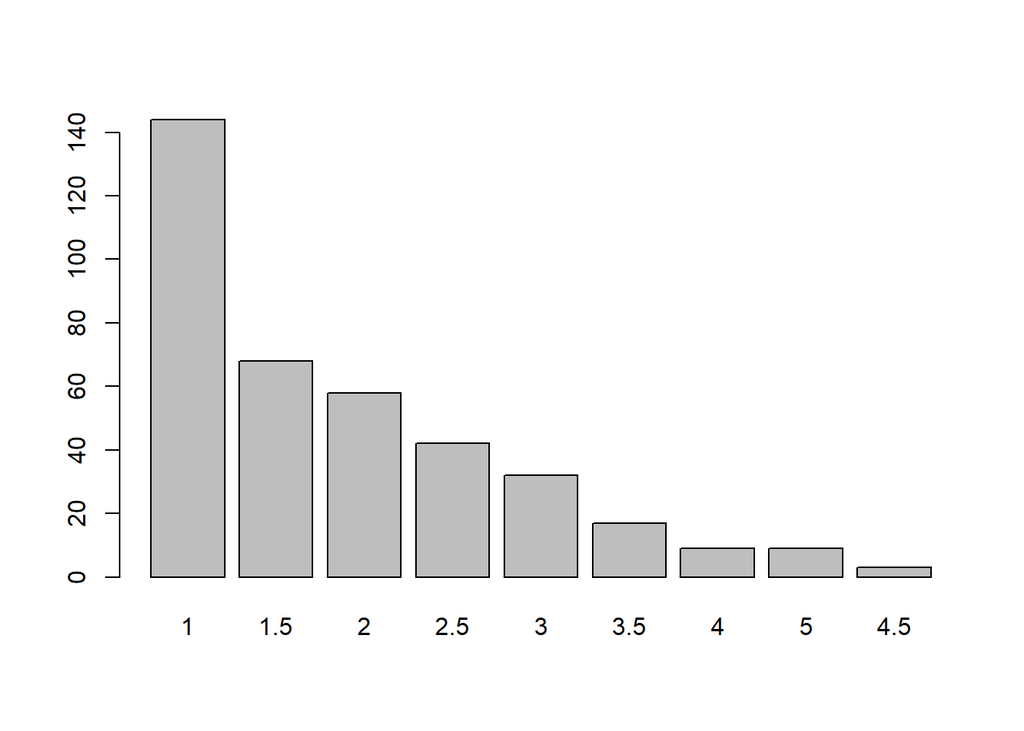

```r
barplot(sort(table(dt_some_col$alc_use),decreasing=T))
```

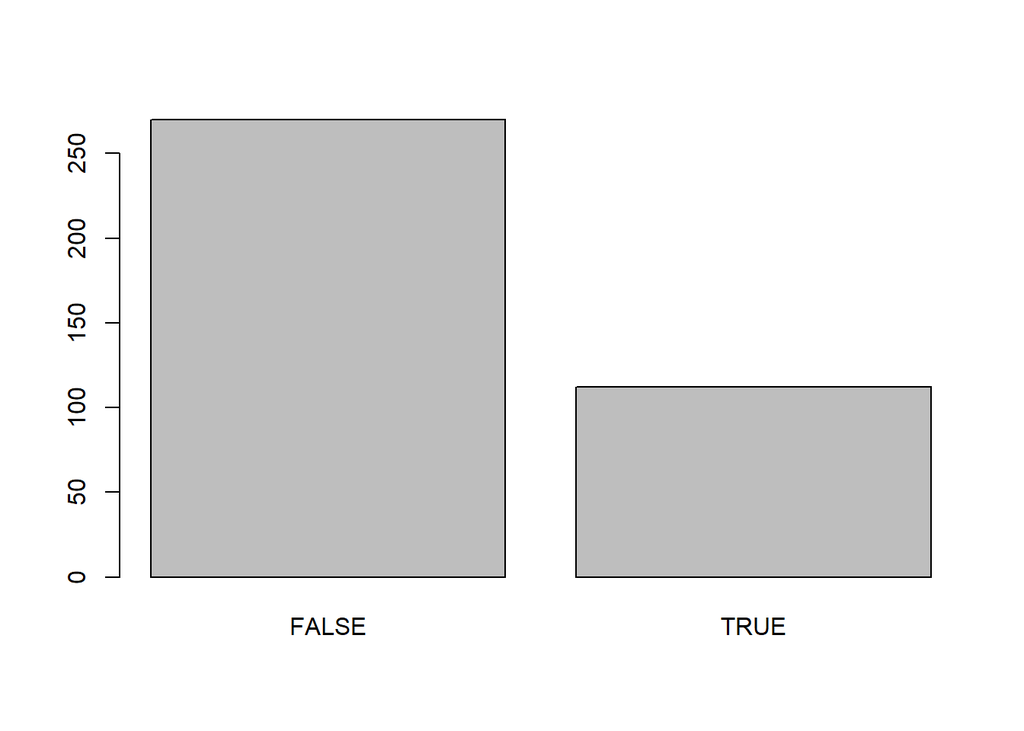

```r
barplot(sort(table(dt_some_col$high_use),decreasing=T))
```

Let’s boxplot the numerical variables of interest

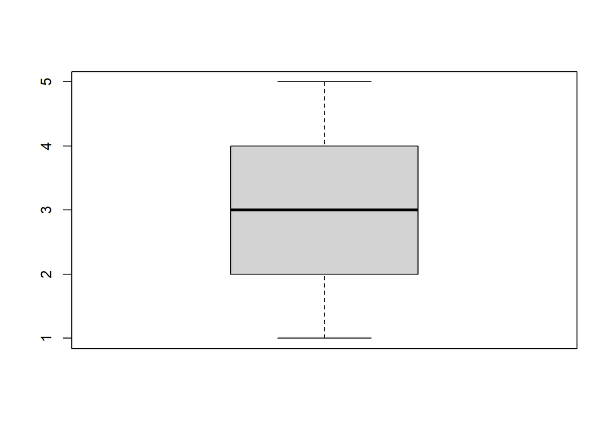

```r
boxplot(dt_some_col$goout)
```

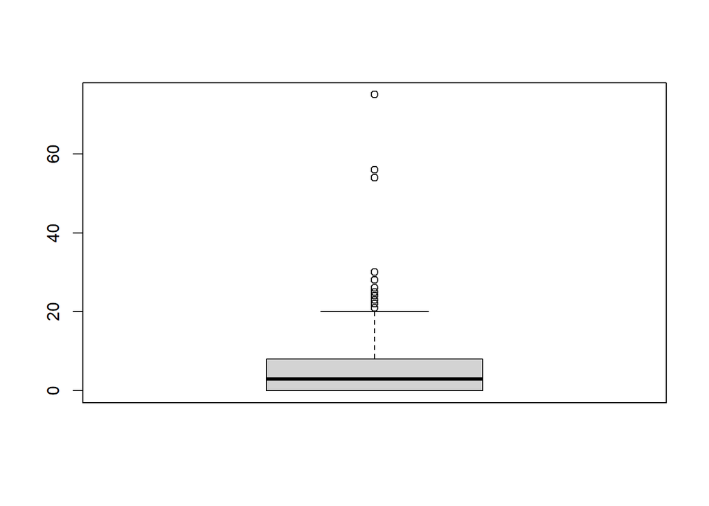

```r
boxplot(dt_some_col$absences)
```

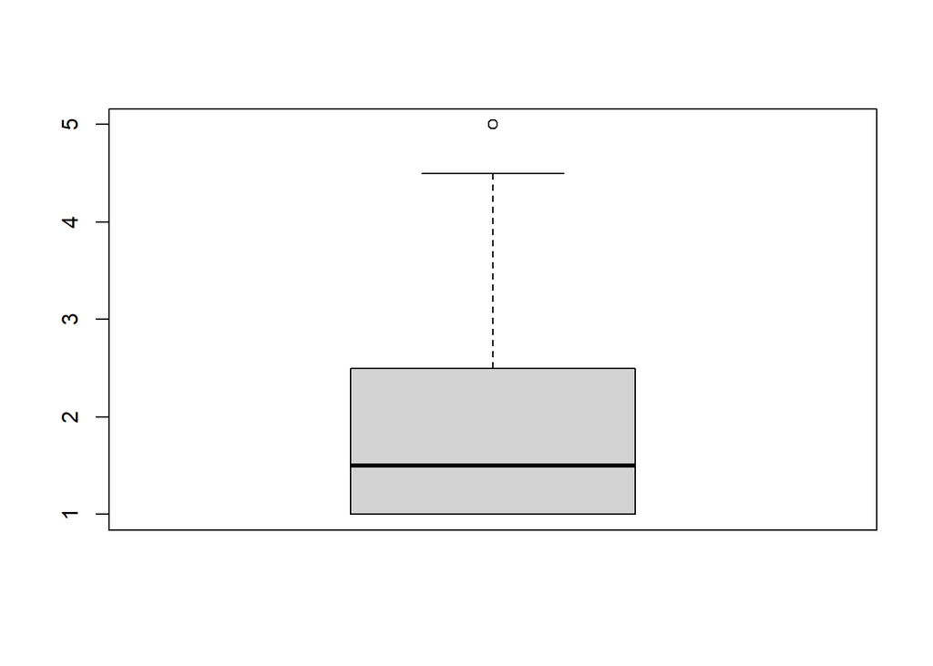

```r
boxplot(dt_some_col$alc_use)
```

And some more

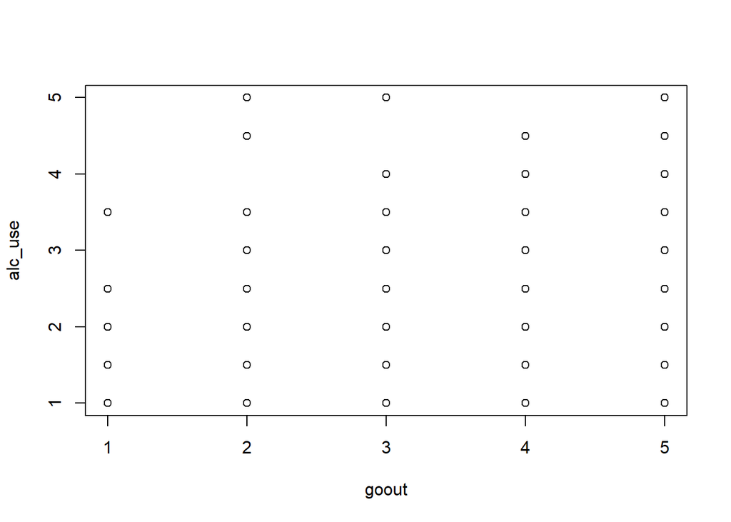

```r
plot(alc_use ~ goout, data=dt_some_col)
```

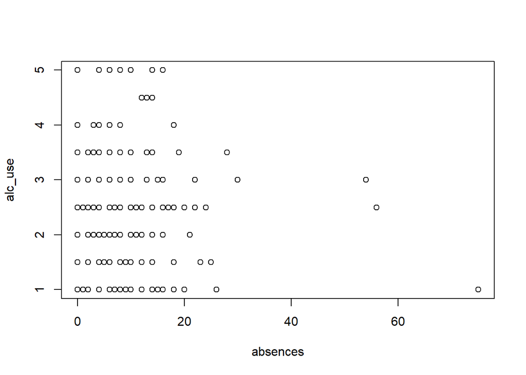

```r
plot(alc_use ~ absences, data=dt_some_col)
```

Alternatively, this code also does the same: “table(dt_some_col$activities, dt_some_col$alc_use)”

## Apply logistic regression model

```r
#set binary variables as factor
dt_some_col$internet <- factor(dt_some_col$internet)
dt_some_col$activities <- factor(dt_some_col$activities)


# make the model with glm()
regres_model <- glm(high_use ~ internet + goout + absences + activities, data = dt_some_col, family = "binomial")

# print out a summary of the model
summary(regres_model)
```

```
##
## Call:
## glm(formula = high_use ~ internet + goout + absences + activities,
##     family = "binomial", data = dt_some_col)
##
## Deviance Residuals:
##     Min       1Q   Median       3Q      Max
## -2.0141  -0.7760  -0.5282   0.9018   2.3876
##
## Coefficients:
##               Estimate Std. Error z value Pr(>|z|)
## (Intercept)   -3.47384    0.51472  -6.749 1.49e-11 ***
## internetyes   -0.08489    0.35507  -0.239 0.811041
## goout          0.76811    0.11960   6.422 1.34e-10 ***
## absences       0.06175    0.01701   3.629 0.000284 ***
## activitiesyes -0.44819    0.25086  -1.787 0.074000 .
## ---
## Signif. codes:  0 '***' 0.001 '**' 0.01 '*' 0.05 '.' 0.1 ' ' 1
##
## (Dispersion parameter for binomial family taken to be 1)
##
##     Null deviance: 462.21  on 381  degrees of freedom
## Residual deviance: 393.79  on 377  degrees of freedom
## AIC: 403.79
##
## Number of Fisher Scoring iterations: 4
```

Based on model summary absence is statistically significant relationship with high alcohol use, because the probability value Pr(>|z|) = 0.000284, thus the model is valid in >99% significance level.  
Students with hight going out behaviour, consumed more alcohol. It is statistically proved because Pr(>|z|) = 1.34e-10, thus our hypothesis is accepted in >99% significance level.  
However, having Internet access seemed not to have relationship with those who had the Internet at home. Because the Pr(>|z|) for this was >0.05, thus is not statistically significant (at least in 95%). Thus, our hypothesis that we assumed those who have Internet at home will not consume more alcohol, would be rejected.  
It is the same as our conclusion of chisq.test explained above!  
Notably, the statistical relationship between having more extra-curriculum activities and alcohol consumption was not valid in 95% significance level, however in 90% because the P value is 0.074. So, it shall be rejected, and we can ignore this variable.

Hence, in fact our model would be  
*alcohol consumption = goingout*0.76811 + absence*0.06175 + (-3.47384)*, becuase *y = ax1 + bx2 + c*

```r
# print out the coefficients of the model
coef(regres_model)
```

```
##   (Intercept)   internetyes         goout      absences activitiesyes
##   -3.47383750   -0.08489077    0.76810971    0.06174629   -0.44819206
```

```r
# compute odds ratios (OR)
OR <- coef(regres_model) %>% exp

# compute confidence intervals (CI)
CI <- confint(regres_model) %>% exp
# bind odds ratios (OR) and confidence intervals (CI) columns together
cbind(OR, CI)
```

```
##                       OR      2.5 %     97.5 %
## (Intercept)   0.03099785 0.01084108 0.08194402
## internetyes   0.91861262 0.46457217 1.88377842
## goout         2.15568752 1.71547363 2.74450680
## absences      1.06369244 1.03125278 1.10286289
## activitiesyes 0.63878199 0.38885454 1.04178158
```

As it shows, two variables of going out and absence has high odds ratio (same as probability in non-logistic regression models). And their confidence interval is still good because it’s very close interval, so the most of values in the variable are like that, thus with high OR value.

```r
# predict() the probability of high_use
probabilities <- predict(regres_model, type = "response")

# add the predicted probabilities to 'dt_some_col'
dt_some_col <- mutate(dt_some_col, probability = probabilities)

# use the probabilities to make a prediction of high_use
dt_some_col <- mutate(dt_some_col, prediction = probability > 0.5)

# see the last ten original classes, predicted probabilities, and class predictions
select(dt_some_col, internet, goout, absences, activities, probability, prediction) %>% tail(10)
```

```
##     internet goout absences activities probability prediction
## 373       no     2        0         no  0.12590977      FALSE
## 374       no     3       14         no  0.42432092      FALSE
## 375       no     3        2         no  0.25999091      FALSE
## 376      yes     3        7        yes  0.21919441      FALSE
## 377      yes     2        0        yes  0.07793785      FALSE
## 378      yes     4        0         no  0.38076807      FALSE
## 379       no     1        0        yes  0.04093710      FALSE
## 380       no     1        0        yes  0.04093710      FALSE
## 381      yes     5        3         no  0.61468746       TRUE
## 382      yes     1        0         no  0.05783324      FALSE
```

```r
# tabulate the target variable versus the predictions
table(high_use = dt_some_col$high_use, prediction = dt_some_col$prediction)
```

```
##         prediction
## high_use FALSE TRUE
##    FALSE   247   23
##    TRUE     71   41
```

Now, 2x2 cross tabulation of predictions versus the actual values  
As it shows, 247 cases of high_use alcohol consumptions were false and were predicted correctly as false, 71 of them were miscalssified.

### **Extra coding 3: Create a nice graph with confusion matrix**

```r
# insprited from https://stackoverflow.com/a/64539733
library('caret')
```

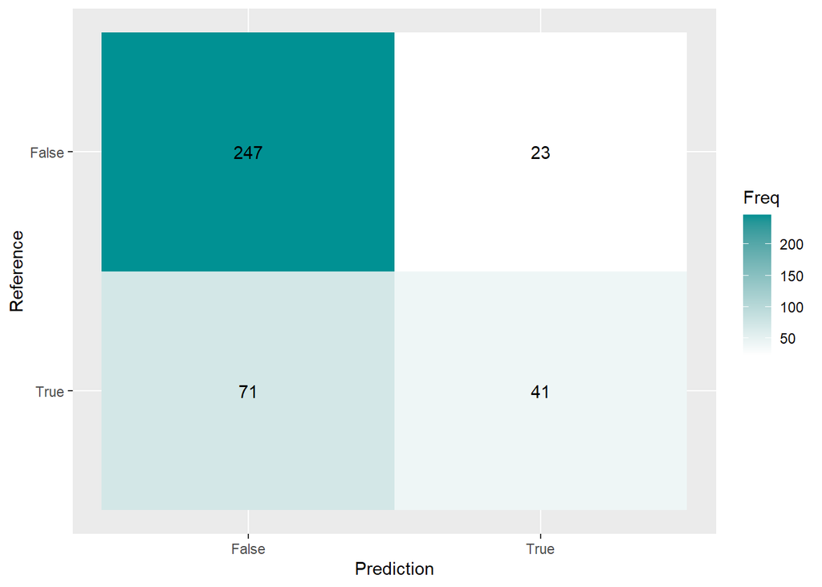

```r
cm <- confusionMatrix(factor(dt_some_col$prediction), factor(dt_some_col$high_use), dnn = c("Prediction", "Reference"))

ggplot(as.data.frame(cm$table), aes(Prediction,sort(Reference,decreasing = T), fill= Freq)) +
  geom_tile() + geom_text(aes(label=Freq)) +
  scale_fill_gradient(low="white", high="#009193") +
  labs(x = "Prediction",y = "Reference") +
  scale_x_discrete(labels=c("False","True")) +
  scale_y_discrete(labels=c("True","False"))
```

Good plots!  
As explained above, it shows that 247 cases of high_use alcohol consumptions were false and were predicted correctly as false, 71 of them were miscalssifed.

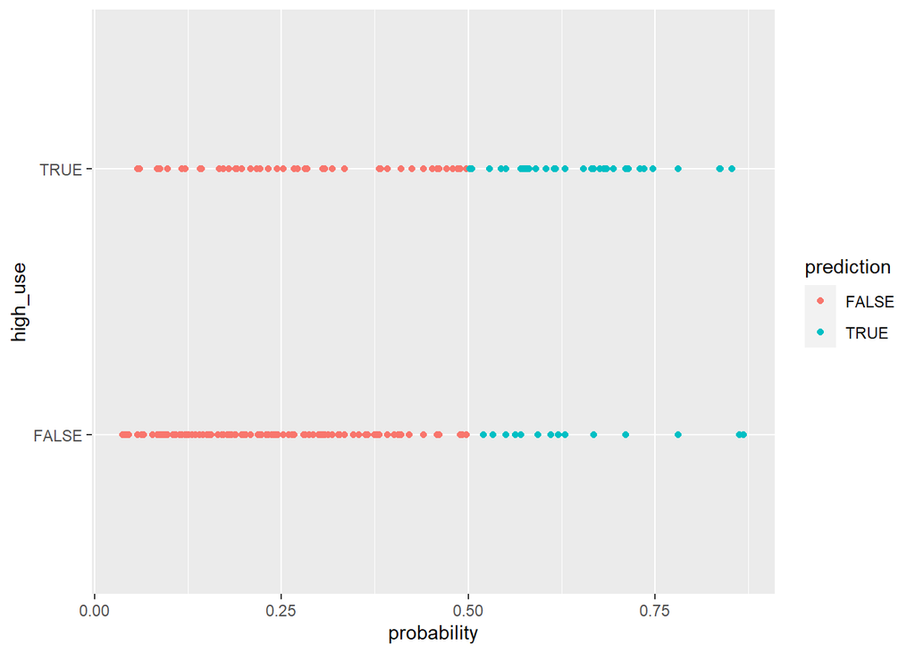

```r
# initialize a plot of 'high_use' versus 'probability' in 'dt_some_col'
g <- ggplot(dt_some_col, aes(x = probability, y = high_use, col = prediction))

# define the geom as points and draw the plot
g + geom_point()
```

```r
# tabulate the target variable versus the predictions
table(high_use = dt_some_col$high_use, prediction = dt_some_col$prediction) %>% prop.table %>% addmargins
```

```
##         prediction
## high_use      FALSE       TRUE        Sum
##    FALSE 0.64659686 0.06020942 0.70680628
##    TRUE  0.18586387 0.10732984 0.29319372
##    Sum   0.83246073 0.16753927 1.00000000
```

Define a loss function (average prediction error)

```r
loss_func <- function(class, prob) {
  n_wrong <- abs(class - prob) > 0.5
  mean(n_wrong)
}

# call loss_func to compute the average number of wrong predictions in the (training) data
loss_func(class = dt_some_col$high_use, prob = dt_some_col$probability)
```

```
## [1] 0.2460733
```

## Bonus: K-fold cross-validation

Perform leave-one-out cross-validation and print out the mean prediction error for the testing data. It divides the observations into k number of folds, leaves-one-out for validation and uses the rest for training, for example, if k=5, uses 4-folds for training and 1-fold for validation

```r
#load library
library(boot)
# cv.glm function from the 'boot' library computes the error and stores it in delta
cv <- cv.glm(data = dt_some_col, cost = loss_func, glmfit = regres_model, K = 2)

# average number of wrong predictions in the cross validation
cv$delta[1]
```

```
## [1] 0.2408377
```

### **Extra coding 4: Make a loop to try different k values**

```r
k = c(2,3,4,5,6,7,8,9,10,11,12,13,14,15,20,25)
for (i in k){
  print(i)
  cv <- cv.glm(data = dt_some_col, cost = loss_func, glmfit = regres_model, K = i)
  # average number of wrong predictions in the cross validation
  print (cv$delta[1])}
```

```
## [1] 2
## [1] 0.2382199
## [1] 3
## [1] 0.2513089
## [1] 4
## [1] 0.2617801
## [1] 5
## [1] 0.2643979
## [1] 6
## [1] 0.2643979
## [1] 7
## [1] 0.2486911
## [1] 8
## [1] 0.2565445
## [1] 9
```

[output cut: 17 more lines]

## Super-Bonus: Create logistic regression with other variables  
I like to add two variables such as romantic (weather or not in a romantic relationship) and famrel (the quality of family relationship).  
I keep the previously significant variables

```r
colnames(data_student_perf_alc)
```

```
##  [1] "school"     "sex"        "age"        "address"    "famsize"
##  [6] "Pstatus"    "Medu"       "Fedu"       "Mjob"       "Fjob"
## [11] "reason"     "nursery"    "internet"   "guardian"   "traveltime"
## [16] "studytime"  "failures"   "schoolsup"  "famsup"     "paid"
## [21] "activities" "higher"     "romantic"   "famrel"     "freetime"
## [26] "goout"      "Dalc"       "Walc"       "health"     "absences"
## [31] "G1"         "G2"         "G3"         "alc_use"    "high_use"
```

```r
variables <- c("romantic", "goout", "absences", "famrel",
               "alc_use", "high_use")
dt_some_col =select(data_student_perf_alc, variables)
dim(dt_some_col)
```

```
## [1] 382   6
```

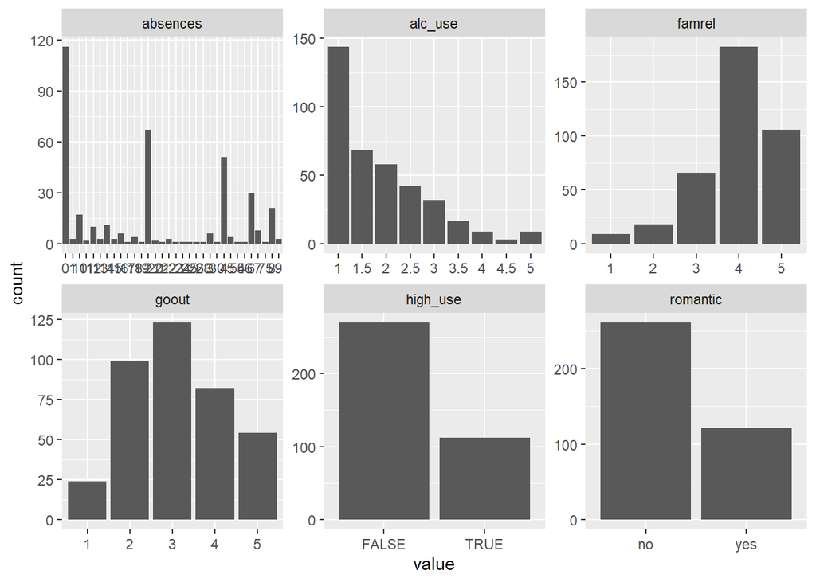

```r
# draw a bar plot of each variable
gather(dt_some_col) %>% ggplot(aes(value)) + facet_wrap("key", scales = "free") + geom_bar()
```

```r
table(dt_some_col$absences)/nrow(dt_some_col)*100
```

```
##
##          0          1          2          3          4          5          6
## 30.3664921  0.7853403 17.5392670  1.5706806 13.3507853  1.0471204  7.8534031
##          7          8          9         10         11         12         13
##  2.0942408  5.4973822  0.7853403  4.4502618  0.5235602  2.6178010  0.7853403
##         14         15         16         17         18         19         20
##  2.8795812  0.7853403  1.5706806  0.2617801  1.0471204  0.2617801  0.5235602
##         21         22         23         24         25         26         28
##  0.2617801  0.7853403  0.2617801  0.2617801  0.2617801  0.2617801  0.2617801
##         30         54         56         75
##  0.2617801  0.2617801  0.2617801  0.2617801
```

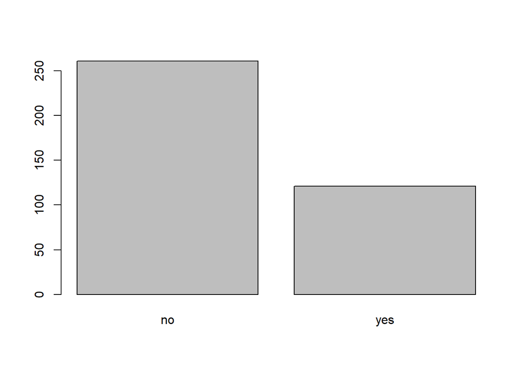

```r
barplot(sort(table(dt_some_col$romantic),decreasing=T))
```

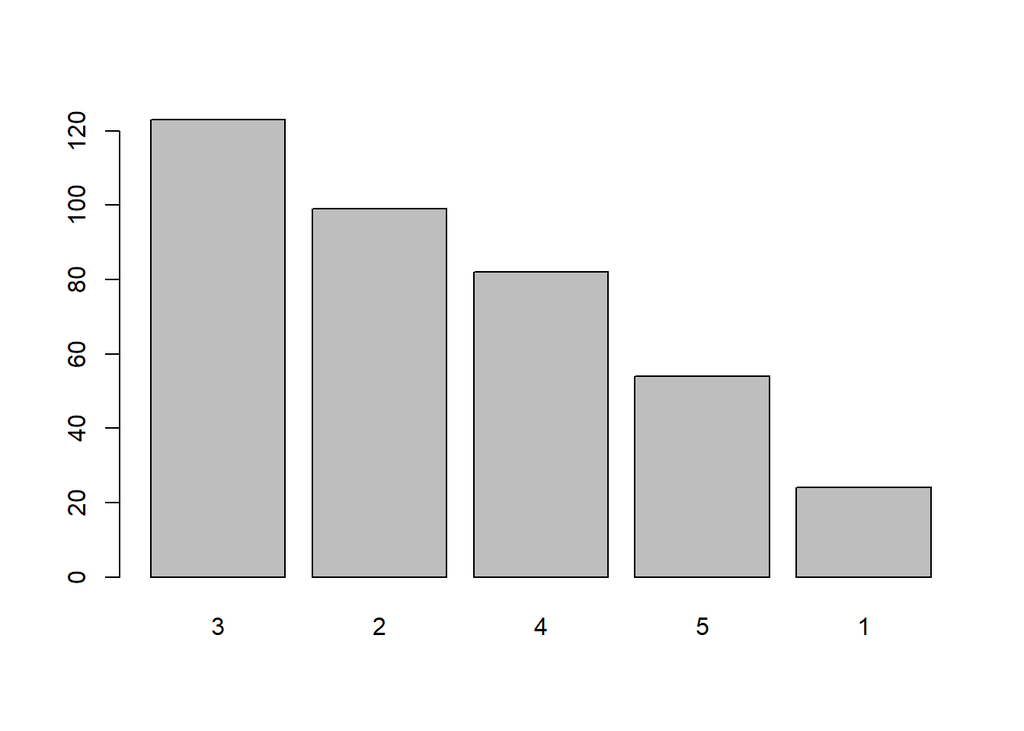

```r
barplot(sort(table(dt_some_col$goout),decreasing=T))
```

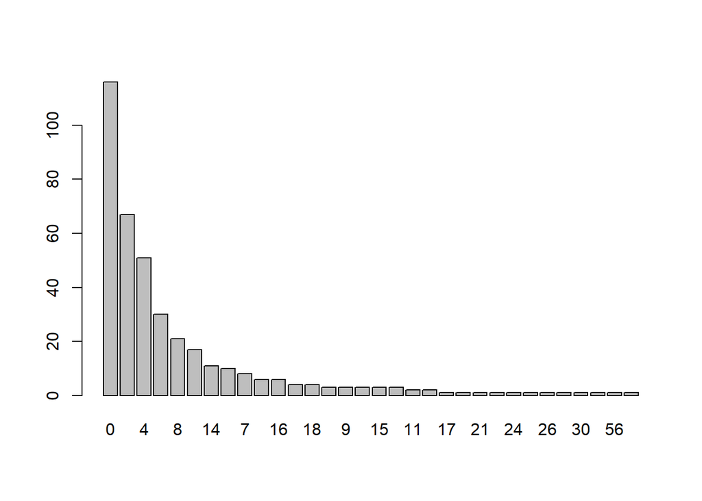

```r
barplot(sort(table(dt_some_col$absences),decreasing=T))
```

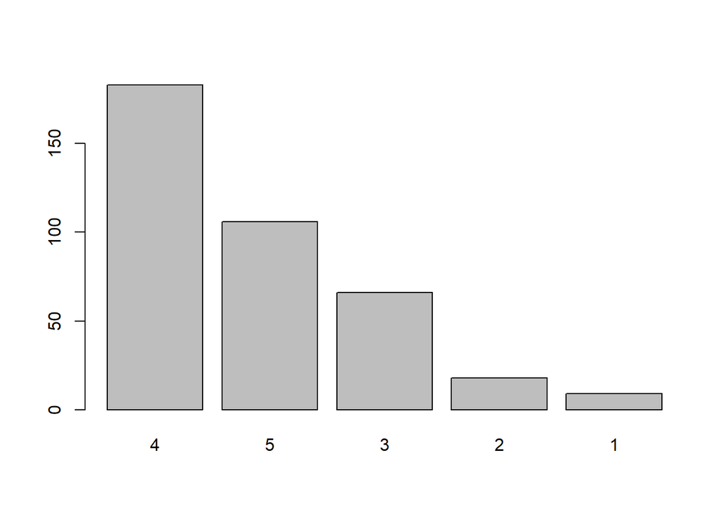

```r
barplot(sort(table(dt_some_col$famrel),decreasing=T))
```

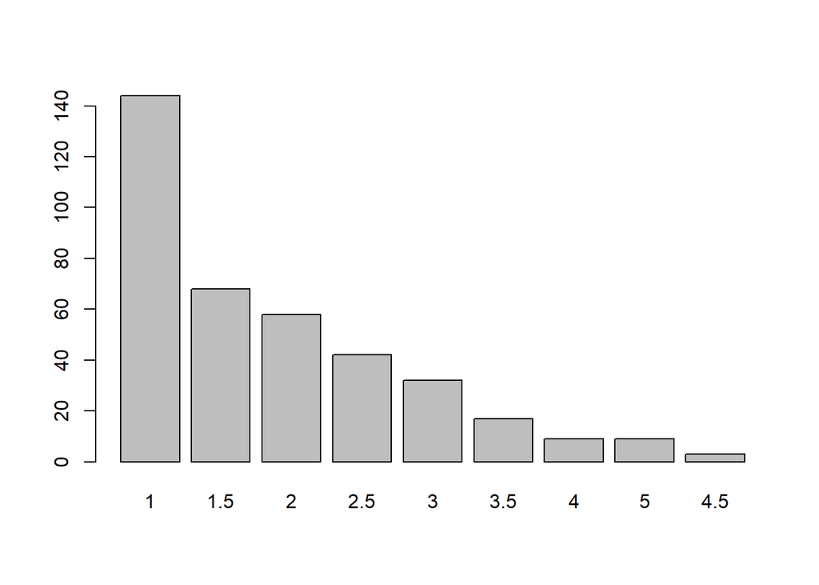

```r
barplot(sort(table(dt_some_col$alc_use),decreasing=T))
```

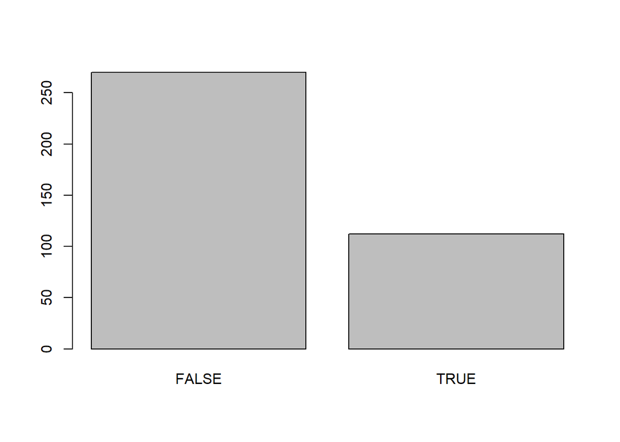

```r
barplot(sort(table(dt_some_col$high_use),decreasing=T))
```

```r
#set binary variables as factor
dt_some_col$romantic <- factor(dt_some_col$romantic)

# find the model with glm()


regres_model <- glm(high_use ~ romantic + goout + absences + famrel, data = dt_some_col, family = "binomial")

# print out a summary of the model
summary(regres_model)
```

```
##
## Call:
## glm(formula = high_use ~ romantic + goout + absences + famrel,
##     family = "binomial", data = dt_some_col)
##
## Deviance Residuals:
##     Min       1Q   Median       3Q      Max
## -1.9599  -0.7789  -0.5080   0.8454   2.4681
##
## Coefficients:
##             Estimate Std. Error z value Pr(>|z|)
## (Intercept) -2.15491    0.63232  -3.408 0.000655 ***
## romanticyes -0.37335    0.27759  -1.345 0.178641
## goout        0.79978    0.12171   6.571 4.99e-11 ***
## absences     0.06001    0.01641   3.656 0.000256 ***
## famrel      -0.41049    0.13511  -3.038 0.002380 **
## ---
## Signif. codes:  0 '***' 0.001 '**' 0.01 '*' 0.05 '.' 0.1 ' ' 1
##
## (Dispersion parameter for binomial family taken to be 1)
##
##     Null deviance: 462.21  on 381  degrees of freedom
## Residual deviance: 386.46  on 377  degrees of freedom
## AIC: 396.46
##
## Number of Fisher Scoring iterations: 4
```

Based on model summary the quality of family relationship (famrel) has statistically significant relationship with high alcohol use, because the probability value Pr(>|z|) = 0.002380, thus the model is valid in >99% significance level.

```r
# print out the coefficients of the model
coef(regres_model)
```

```
## (Intercept) romanticyes       goout    absences      famrel
## -2.15490562 -0.37335072  0.79978011  0.06000845 -0.41048560
```

```r
# compute odds ratios (OR)
OR <- coef(regres_model) %>% exp

# compute confidence intervals (CI)
CI <- confint(regres_model) %>% exp
# bind odds ratios (OR) and confidence intervals (CI) columns together
cbind(OR, CI)
```

```
##                    OR      2.5 %    97.5 %
## (Intercept) 0.1159141 0.03245399 0.3900847
## romanticyes 0.6884237 0.39504416 1.1763720
## goout       2.2250516 1.76429361 2.8462267
## absences    1.0618455 1.03000291 1.0997256
## famrel      0.6633281 0.50735265 0.8632692
```

```r
# predict() the probability of high_use
probabilities <- predict(regres_model, type = "response")

# add the predicted probabilities to 'dt_some_col'
dt_some_col <- mutate(dt_some_col, probability = probabilities)

# use the probabilities to make a prediction of high_use
dt_some_col <- mutate(dt_some_col, prediction = probability > 0.5)

# see the last ten original classes, predicted probabilities, and class predictions
select(dt_some_col, romantic , goout , absences , famrel, probability, prediction) %>% tail(10)
```

```
##     romantic goout absences famrel probability prediction
## 373       no     2        0      4  0.09999431      FALSE
## 374       no     3       14      5  0.27530426      FALSE
## 375       no     3        2      5  0.15604215      FALSE
## 376      yes     3        7      4  0.20573973      FALSE
## 377       no     2        0      5  0.06863981      FALSE
## 378       no     4        0      4  0.35486376      FALSE
## 379       no     1        0      1  0.14608898      FALSE
## 380       no     1        0      1  0.14608898      FALSE
## 381       no     5        3      2  0.76906675       TRUE
## 382       no     1        0      4  0.04755851      FALSE
```

```r
# tabulate the target variable versus the predictions
table(high_use = dt_some_col$high_use, prediction = dt_some_col$prediction)
```

```
##         prediction
## high_use FALSE TRUE
##    FALSE   251   19
##    TRUE     66   46
```

As shown above, 251 cases of high_use alcohol consumptions were false and were predicted correctly as false, 66 of them were miscalssifed, so the accuracy improved.  
Moreover, the numbers in diagonal (251 and 46) were increased compared to above model, which shoes the increase of the corrected predicted values, and hence, increase in model accuracy

```r
# call loss_func to compute the average number of wrong predictions in the (training) data
loss_func(class = dt_some_col$high_use, prob = dt_some_col$probability)
```

```
## [1] 0.2225131
```

K-fold cross-validation  
As explained also above, let’s perform leave-one-out cross-validation and print out the mean prediction error for the testing data  
It divids the observations into k number of folds, leaves-one-out for validation and uses the rest for training, for example, if k=5, uses 4 folds for training and 1 fold for validation

```r
#load library
library(boot)
# cv.glm function from the 'boot' library computes the error and stores it in delta
cv <- cv.glm(data = dt_some_col, cost = loss_func, glmfit = regres_model, K = 2)

# average number of wrong predictions in the cross validation
cv$delta[1]
```

```
## [1] 0.2591623
```

### **Extra coding 5: Try different k values using a loop for new model**

```r
k = c(2,3,4,5,6,7,8,9,10,11,12,13,14,15,20,25)
for (i in k){
  print(i)
  cv <- cv.glm(data = dt_some_col, cost = loss_func, glmfit = regres_model, K = i)
  # average number of wrong predictions in the cross validation
  print (cv$delta[1])}
```

```
## [1] 2
## [1] 0.2303665
## [1] 3
## [1] 0.2408377
## [1] 4
## [1] 0.2277487
## [1] 5
## [1] 0.2251309
## [1] 6
## [1] 0.2329843
## [1] 7
## [1] 0.2251309
## [1] 8
## [1] 0.2172775
## [1] 9
```

[output cut: 17 more lines]

So, the accuracy of crossvalidation improved by adding the new variable (quality of family relation), because the average number of wrong predictions (shown by cv$delta[1] in above) decreased